# Nile River Shiny App

2024-01-15

## Background: The River Nile

The “Nile” dataset contains Durbin and Koopman’s 2001 time series measuring the annual flow of the Nile River at Aswan Dam between the years 1871 and 1970.

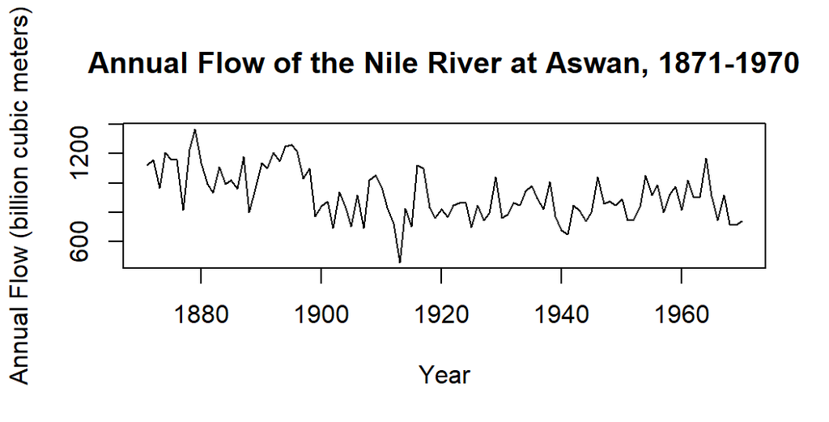

This Shiny App allows users to more easily explore this data set by selecting periods of time within the series and examining key measures from that subset of the data.

## What The App Does

- Allows users to select start and end years for the subset period, using slider bars;
- Displays the timeseries chart, with the selected section of the line highlighted in blue;
- Calculates the values of the minimum, maximum, mean, and median water flow during that period, as well as the average change per year in water flow during the period;
- Displays the results of those calculations in a table below the chart.

This will help users efficiently explore the data set.

## How to Use the App

1. Choose a starting year on the first slidebar
2. Choose an ending year on the second slidebar
3. Look at the results! The blue section of the plot shows the years you’ve selected, and the table below shows calculated statistics for that time period

*Note: The “ending year” slider will automatically adjust to begin with the “starting year” you’ve selected.

### If, for example, you select the interwar years (1918-1939) you’d get these results:

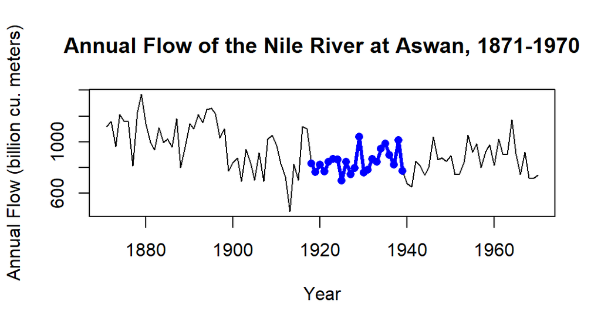

[output not shown]